# Part 1: Binomial logistic regression

Allison Horst

1/17/2021

### Intro

In lectures this week, we are learning about logistic regression - where based on predictor variables, we can estimate the probability of different discrete outcomes for a categorical variable. If there are only two mutually exclusive outcomes, we might use *binary logistic regression*, and for > 2 mutually exclusive outcomes we might use *multinomial logistic regression.* If the dependent variable is *ordinal* (discrete levels with meaningful order), we might use *ordinal logistic regression*, which we’ll get to next week.

Here, we will use *binary logistic regression* to find probabilities that a penguin is species Chinstrap or Adelie, based on flipper length, body mass, and sex.

### 1. Binary logistic regression

#### a. Exploration with `ggpairs`

First, let’s remind ourselves of the penguins data. We will only consider variables species, bill depth, bill length, body mass, flipper length and sex.

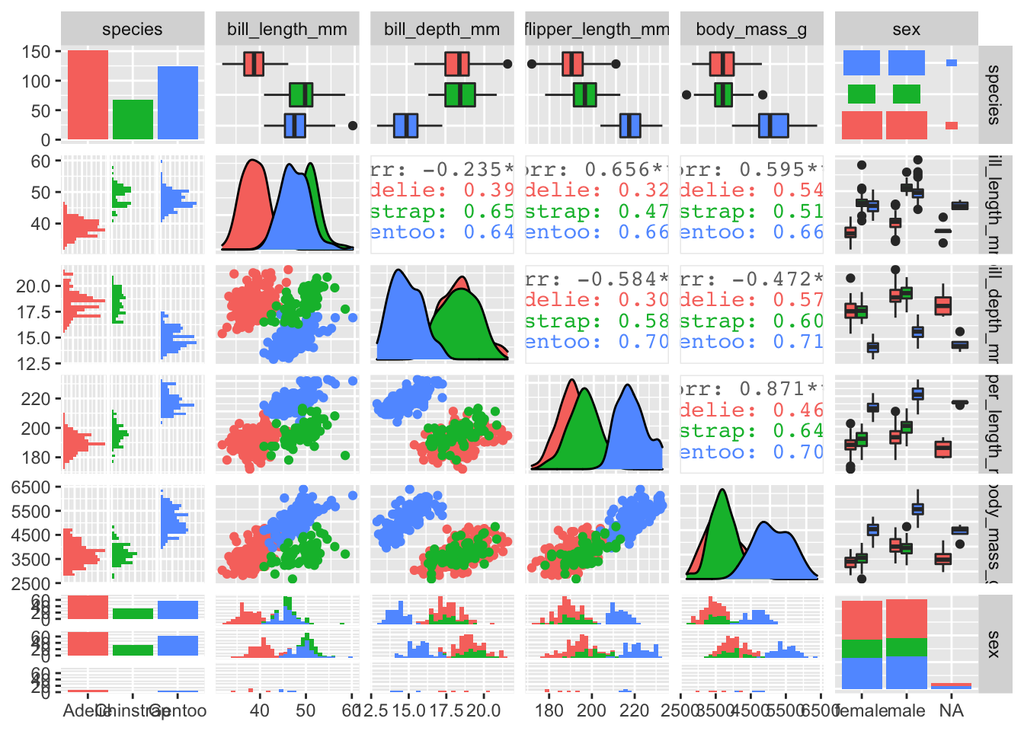

```r
penguins %>%
  select(species, bill_length_mm:sex) %>%
  ggpairs(aes(color = species))
```

We want to explore the relationship between bill length, depth, mass, flipper length, and sex (those will be our explanatory variables) and penguin species (that’s our dependent variable).

To start, we’ll just choose two species (those that are *most similar* across these variables to make it interesting), Adelie and Chinstrap penguins. **Remember:** you could explore this with a PCA biplot!

#### b. Make subset with Adelie and Chinstrap penguins

```r
adelie_chinstrap <- penguins %>%
  filter(species %in% c("Adelie", "Chinstrap")) %>%
  mutate(species = fct_drop(species)) # This will drop a factor level that doesn't appear (otherwise Gentoo will still show up as a factor level, even though there are no remaining observations for Gentoo penguins...)

# Check the levels (note here Adelie is before Chinstrap, so Adelie will be 0, Chinstrap will be 1)
levels(adelie_chinstrap$species)
```

```
## [1] "Adelie"    "Chinstrap"
```

#### c. Let’s just check out trends across variables for those two species

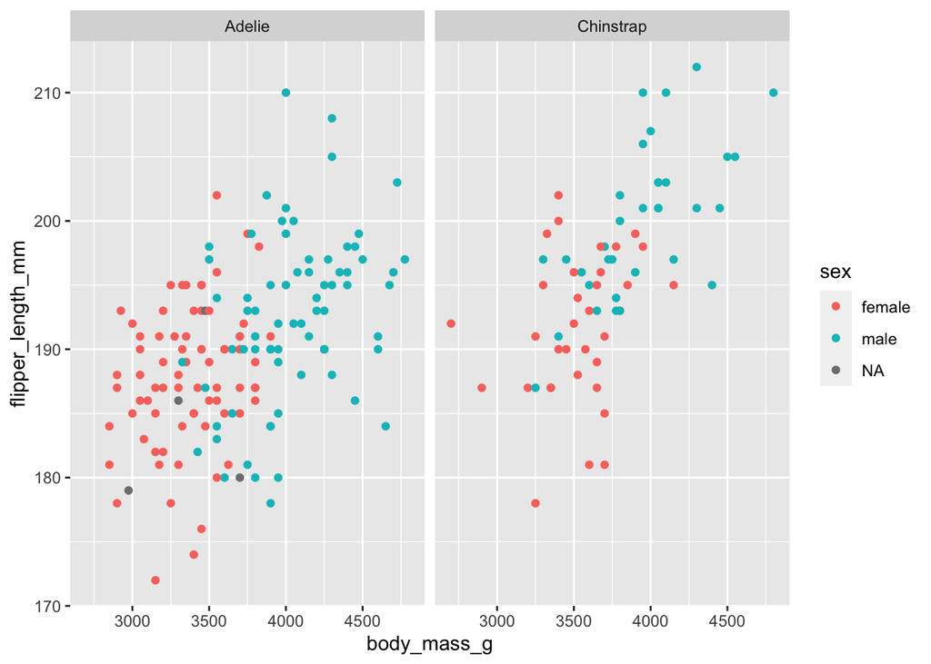

```r
ggplot(data = adelie_chinstrap, aes(x = body_mass_g, y = flipper_length_mm)) +
  geom_point(aes(color = sex)) +
  facet_wrap(~species)
```

#### d. Binary logistic regression

Let’s try with three predictor variables: penguin body mass, flipper length, and sex.

```r
adelie_chinstrap_blr <- glm(species ~ body_mass_g + flipper_length_mm + sex,
                            data = adelie_chinstrap,
                            family = "binomial")
```

Look at the model:

```r
adelie_chinstrap_blr
```

```
##
## Call:  glm(formula = species ~ body_mass_g + flipper_length_mm + sex,
##     family = "binomial", data = adelie_chinstrap)
##
## Coefficients:
##       (Intercept)        body_mass_g  flipper_length_mm            sexmale
##        -3.161e+01         -8.576e-04          1.778e-01         -5.716e-01
##
## Degrees of Freedom: 213 Total (i.e. Null);  210 Residual
##   (6 observations deleted due to missingness)
## Null Deviance:       267.6
## Residual Deviance: 226.4     AIC: 234.4
```

```r
summary(adelie_chinstrap_blr)
```

```
##
## Call:
## glm(formula = species ~ body_mass_g + flipper_length_mm + sex,
##     family = "binomial", data = adelie_chinstrap)
##
## Deviance Residuals:
##     Min       1Q   Median       3Q      Max
## -1.9456  -0.8195  -0.5581   1.0065   2.3698
##
## Coefficients:
##                     Estimate Std. Error z value Pr(>|z|)
## (Intercept)       -3.161e+01  5.784e+00  -5.465 4.63e-08 ***
## body_mass_g       -8.576e-04  5.428e-04  -1.580    0.114
## flipper_length_mm  1.778e-01  3.236e-02   5.495 3.91e-08 ***
## sexmale           -5.716e-01  4.499e-01  -1.270    0.204
## ---
## Signif. codes:  0 '***' 0.001 '**' 0.01 '*' 0.05 '.' 0.1 ' ' 1
##
## (Dispersion parameter for binomial family taken to be 1)
##
##     Null deviance: 267.57  on 213  degrees of freedom
## Residual deviance: 226.45  on 210  degrees of freedom
##   (6 observations deleted due to missingness)
## AIC: 234.45
##
## Number of Fisher Scoring iterations: 4
```

```r
# Get a tidy version w/ broom:
blr_tidy <- broom::tidy(adelie_chinstrap_blr)
```

How can we start thinking about this?

- These are coefficients for the log-linear model (e.g. these are coefficients for the predictor variables that relate to the *log odds* of the “Chinstrap” outcome).
- The null hypothesis for coefficients is that they = 0
- The coefficient for body mass, 0, indicates that on average we expect the log odds of a penguin being a Chinstrap (remember, that’s the ‘1’ outcome) decreases by 0 for each 1 g increase in penguin body mass (see `summary(blr_tidy)` - this coefficient is not significant).

Does this align with the mass comparisons for Chinstraps & Adelies we see?

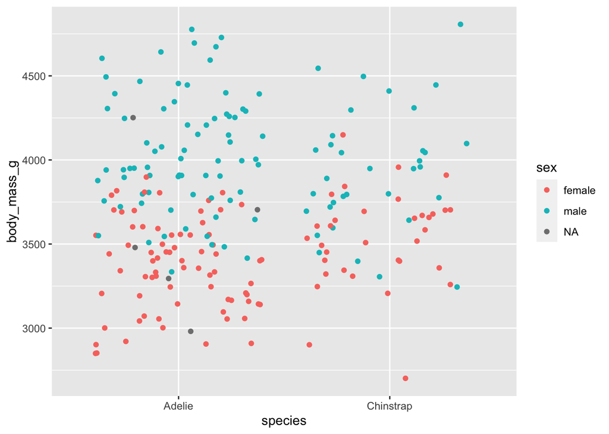

```r
ggplot(data = adelie_chinstrap, aes(x = species, y = body_mass_g)) +
  geom_jitter(aes(color = sex))
```

Does this align with the flipper comparisons for Chinstraps & Adelies we see?

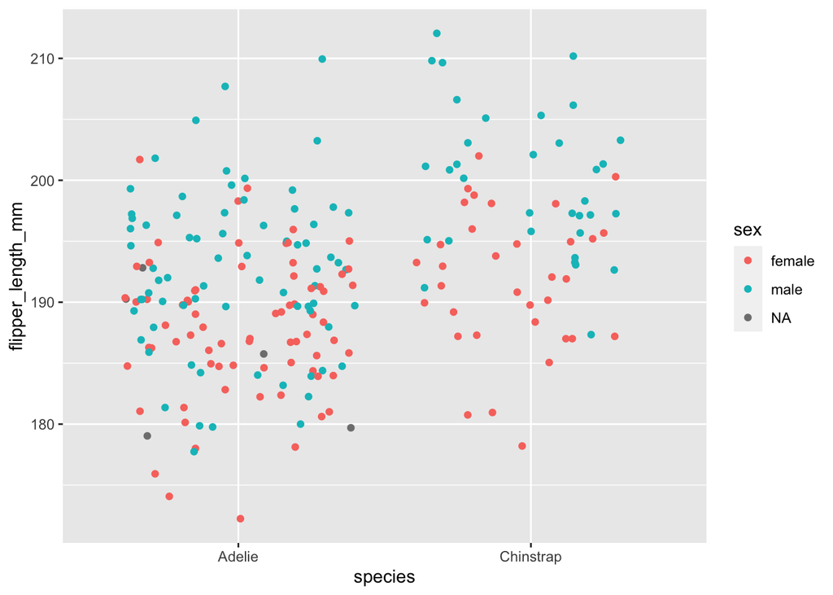

```r
ggplot(data = adelie_chinstrap, aes(x = species, y = flipper_length_mm)) +
  geom_jitter(aes(color = sex))
```

- The coefficient for sex, -0.57, indicates that on average we expect the log odds of a penguin being a Chinstrap (remember, that’s the ‘1’ outcome) decreases by -0.57 if the penguin is Male, compared to Female (this is a weird example – but you can imagine relevant interpretations for other scenarios e.g. “The odds of supporting a bill for conservation (Y/N) increases if the individual identifies as an Environmentalist, compared to those who identify as Not and Environmentalist).”

But log odds are challenging to interpret. Let’s find actual *probabilities* associated with a penguin being Adelie or Chinstrap, based on the selected variables and the model outcome.

Adding `type.predict = "response"` here converts the log odds (link), the default reported, to the probability of being Chinstrap for each observation.

```r
blr_fitted <- adelie_chinstrap_blr %>%
  broom::augment(type.predict = "response")
```

Look at the outcome data frame.

That shows us the probability (in the `.fitted` column) of a penguin being a Chinstrap based on the three variables `body_mass_g`, `flipper_length_mm`, and `sex`. Take a moment to look through the probabilities. Are there some that have a high probability of being a Chinstrap, but are actually Adelies? YES (e.g. Row 91 shows a probability of 0.78 of being a Chinstrap, based on this model…). But *most* of the actual Adelies in the dataset have a higher probability of being an Adelie based on the model (probability of a Chinstrap < 0.5).

A number of the actual Chinstraps (if we weren’t looking at the actual observation) have, based on the model, a higher probability of being an Adelie by classification. This demonstrates why, in Machine Learning, we need a training dataset (which we’d use to create the model), then a totally separate test dataset to see how successfully it classifies the outcome (e.g. penguin species here).

Let’s do a couple of quick visualizations, with flipper length (the only significant coefficient) on the x-axis and probability of being a Chinstrap on the y-axis:

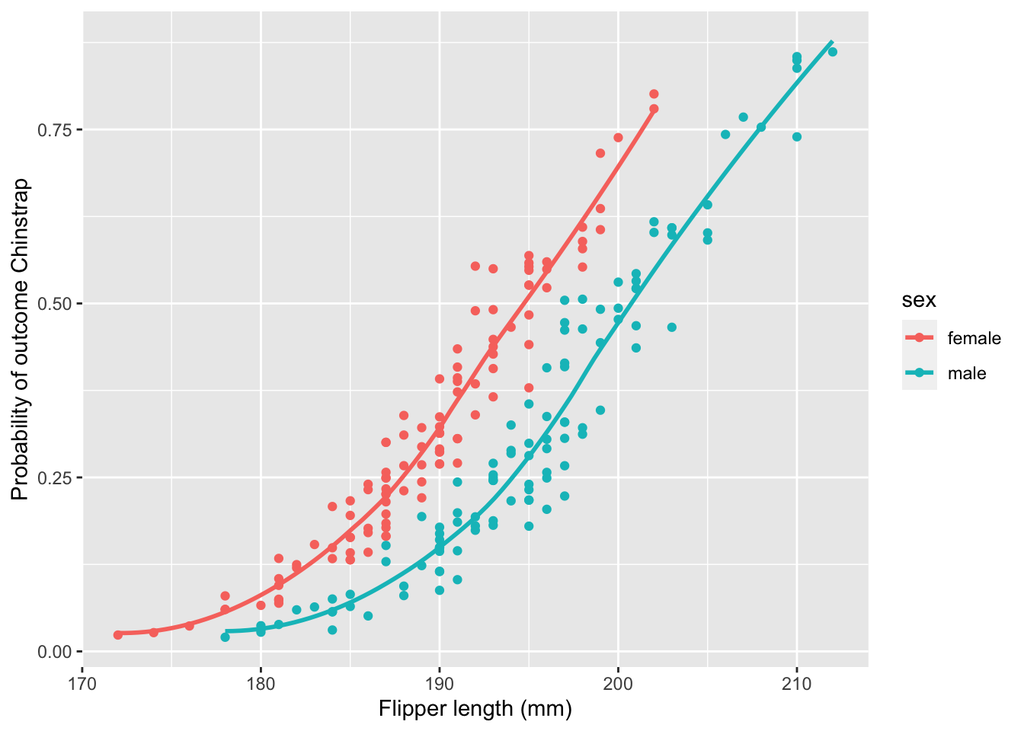

```r
ggplot(data = blr_fitted, aes(x = flipper_length_mm, y = .fitted)) +
  geom_point(aes(color = sex)) +
  geom_smooth(aes(color = sex), se = FALSE) +
  labs(x = "Flipper length (mm)",
       y = "Probability of outcome Chinstrap")
```

#### Visualization of p(Chinstrap) by variable

The `jtools::effect_plot()` function provides some quick model plotting. Note: for more customized visualization of model predictions, you may want to create a new “test” data frame of theoretical values, then use the `predict()` function to append predicted probabilities before plotting in `ggplot()`.

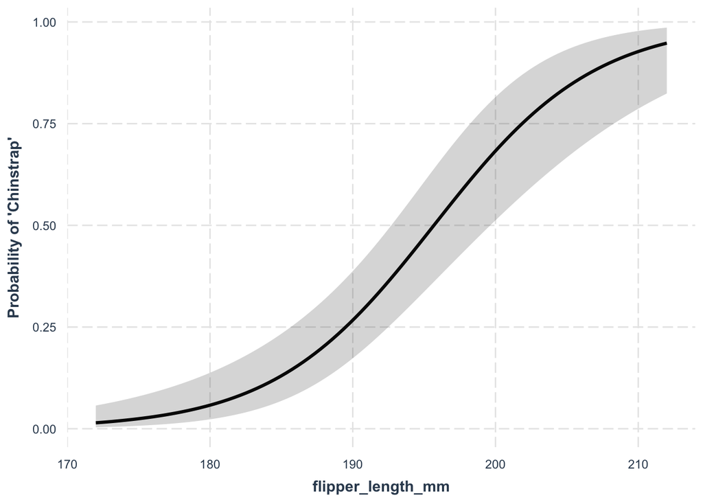

```r
# For flipper length:
effect_plot(adelie_chinstrap_blr,
            pred = flipper_length_mm,
            interval = TRUE,
            y.label = "Probability of 'Chinstrap'")
```

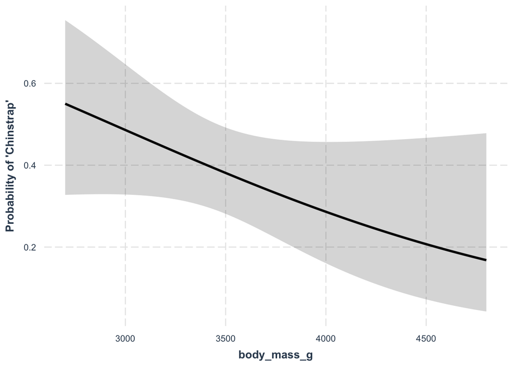

```r
# For body mass:
effect_plot(adelie_chinstrap_blr,
            pred = body_mass_g,
            interval = TRUE,
            y.label = "Probability of 'Chinstrap'")
```

#### Predictions for new values with `predict()`

What is the probability that a female penguin weight 3410 g with a flipper length of 192 mm will be Chinstrap?

```r
ex_1 <- predict(adelie_chinstrap_blr,
                data.frame(sex = "female",
                body_mass_g = 3410,
                flipper_length_mm = 192),
                type = "response")

# Based on the model, the probability that this penguin is a Chinstrap is 0.4.
```

You can also feed in a new data frame, with multiple penguin observations, to get model probability estimates for more than one penguin:

```r
new_df <- data.frame(
  sex = c("male", "male", "female"),
  body_mass_g = c(3298, 4100, 3600),
  flipper_length_mm = c(212, 175, 180)
)

ex_2 <- predict(adelie_chinstrap_blr,
                new_df,
                type = "response")
```